# MA304: How Does Weather Relate to Crime Type and Frequency in Colchester, 2024?

RegNo: 2401838

April 24, 2025

## 1. Introduction

This study explores the relationship between the weather and street-level crime in Colchester over the course of 2024. The primary research question guiding the analysis is: **To what extent do temperature, rainfall, and humidity predict variation in the frequency and type of crime?**

To address this, the study draws on crime and weather datasets, which are aggregated and examined across multiple dimensions. The analysis begins with univariate and bivariate summaries to understand the baseline distributions and simple associations, followed by temporal trend analysis and spatial mapping to uncover seasonality and geographic distribution. A series of linear regression models are then used to evaluate the statistical strength of weather-related predictors.

## 2. Data Preparation

This section loads and prepares the crime and weather datasets for analysis. We convert date formats, remove rows with missing coordinates, and ensure variables are structured correctly for time series and spatial mapping.

Two datasets are used: - `crime24.csv`, which contain monthly street-level crime data for 2024 in Colchester, and - `temp24.csv`, containing daily weather metrics from a local station near Colchester.

Basic cleaning and column transformation is applied to enable merging and accurate visual analysis.

### 2.1 Load Datasets

```r
# Load the datasets
crime <- read_csv("crime24.csv")
weather <- read_csv("temp24.csv")

# Clean and prepare crime data
crime <- crime %>%
  filter(!is.na(lat), !is.na(long)) %>%
  mutate(
    date = ym(date),                     # ensure proper date parsing
    month = floor_date(date, "month")     # extract month for joining
  )

# Clean and prepare weather data
weather <- weather %>%
  mutate(
    Date = ymd(Date),                     # ensure Date is parsed correctly
    month = floor_date(Date, "month")     # extract month for joining
  )

# Aggregate monthly crime counts
crime_monthly <- crime %>%
  group_by(month) %>%
  summarise(monthly_count = n(), .groups = "drop")

# Aggregate monthly weather data
weather_monthly <- weather %>%
  group_by(month) %>%
  summarise(
    TemperatureCAvg = mean(TemperatureCAvg, na.rm = TRUE),
    HrAvg = mean(HrAvg, na.rm = TRUE),
    Precmm = sum(Precmm, na.rm = TRUE),
    .groups = "drop"
  )

# Merge datasets on by month
crime_weather_monthly <- left_join(crime_monthly, weather_monthly, by = "month")
```

## 3. Univariate Analysis

To establish a baseline understanding of the data, this section explores the distribution of individual variables within the crime and weather datasets. Summary statistics and visualisations are used to describe the frequency and variation of recorded crime incidents, as well as key weather metrics such as temperature, rainfall, and humidity. By examining these variables in isolation, we can identify dominant crime categories, seasonal patterns, and any potential skewness or irregularities that may influence the following analyses.

3.1 Crime Frequency Table

The first step in the analysis is to examine the overall frequency of different crime types recorded in Colchester during 2024. The table below displays the number of incidents per category, ranked in descending order. This provides an initial sense of which offences are most common and may warrant further investigation.

```r
# Calculate crime frequency
crime_freq <- crime %>%
  count(category, sort = TRUE)

# Creating a frequeny table
DT::datatable(crime_freq,
              options = list(pageLength = 5),
              colnames = c("Crime Type", "Frequency"),
              caption = "Table 1: Frequency of Each Crime Type in 2024")
```

|  | Crime Type | Frequency |
| --- | --- | --- |
| 1 | violent-crime | 2420 |
| 2 | anti-social-behaviour | 710 |
| 3 | shoplifting | 629 |
| 4 | criminal-damage-arson | 479 |
| 5 | public-order | 458 |
| 6 | other-theft | 412 |
| 7 | vehicle-crime | 270 |
| 8 | drugs | 265 |
| 9 | burglary | 171 |
| 10 | bicycle-theft | 149 |

[output cut: 4 more lines]

### 3.2 Top 10 Crime Types in Colchester 2024

Next, we visualise the overall distribution of reported crime types in Colchester during 2024. The bar chart below displays the ten most frequent crime categories, providing a clear overview of which types dominate the dataset.

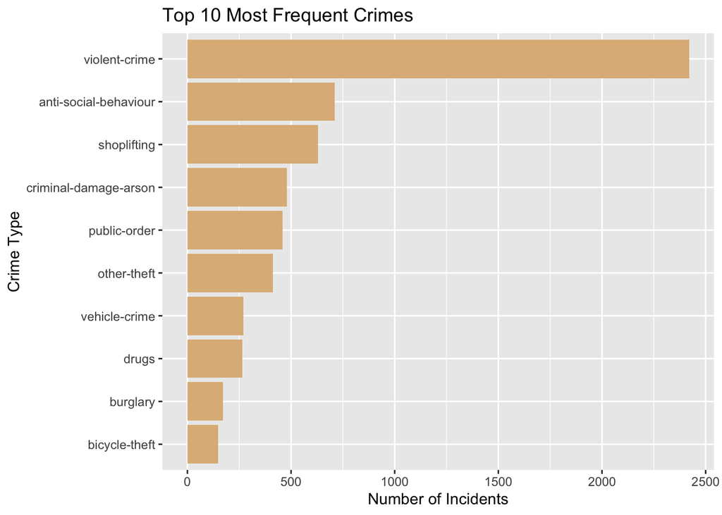

```r
# Selecting top 10 crimes
top10 <- crime_freq %>% slice_max(n, n = 10)

# Plotting crime type against frequency
ggplot(top10, aes(x = reorder(category, n), y = n)) +
  geom_col(fill = "burlywood") +
  coord_flip() +
  labs(title = "Top 10 Most Frequent Crimes",
       x = "Crime Type", y = "Number of Incidents")
```

*Figure 1: Bar plot of the ten most commonly reported crime categories in Colchester, 2024.*

The chart shows that **violent crime** is by far the most commonly reported offence, with more than double the incidents of the next most frequent type. **Anti-social behaviour** and **shoplifting** also contribute significantly to the overall crime landscape.

Together, these top three categories account for the majority of incidents, suggesting that interventions targeting these areas could yield the greatest impact. In contrast, crimes like **bicycle theft** and **burglary** are less common, though still important to monitor.

### 3.3 Monthly Crime Trend

To examine how crime levels vary over time, this section plots the total number of reported incidents by month throughout 2024. Analysing temporal patterns is essential for identifying potential seasonality or recurring trends that may relate to changes in routine activity, public events, or environmental conditions.

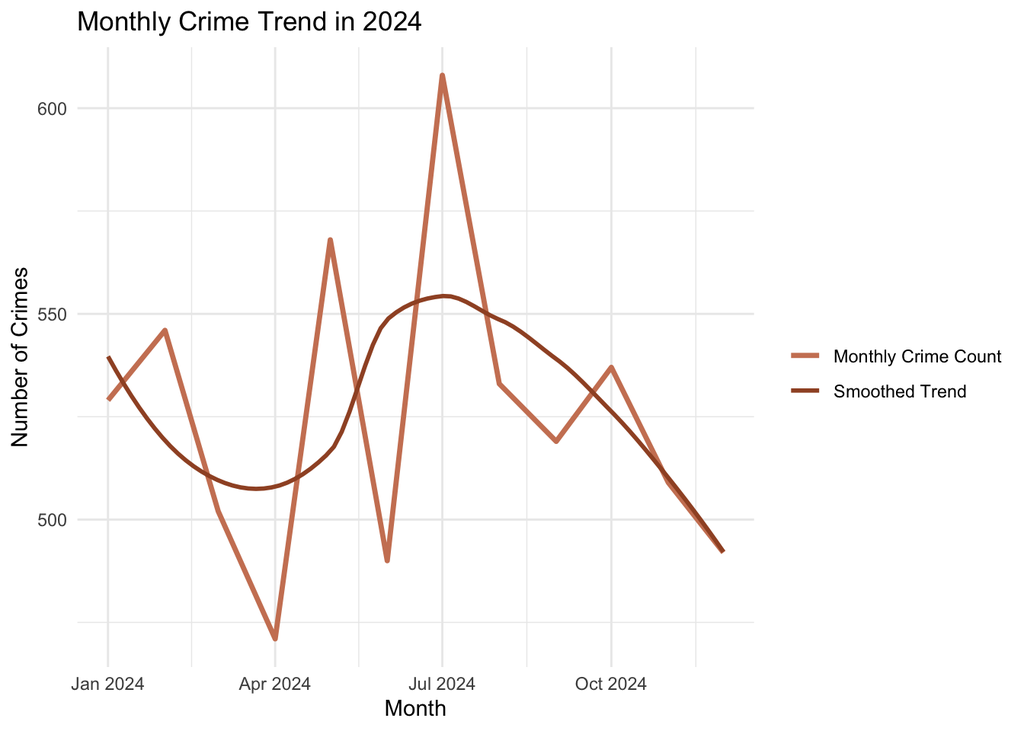

```r
# Calculating monthly crime rate
monthly_crime <- crime %>% count(date)

# Plotting monthly crime count
ggplot(monthly_crime, aes(x = date)) +
  geom_line(aes(y = n, color = "Monthly Crime Count"), size = 1.2) +
  geom_smooth(aes(y = n, color = "Smoothed Trend"), method = "loess", se = FALSE) +
  labs(
    title = "Monthly Crime Trend in 2024",
    x = "Month",
    y = "Number of Crimes",
    color = ""
  ) +
  scale_color_manual(values = c("Monthly Crime Count" = "lightsalmon3", "Smoothed Trend" = "sienna")) +
  theme_minimal()
```

*Figure 2: Time series of total monthly crime counts in 2024, with loess smoothing to illustrate seasonal variation.*

### 3.4 Monthly Crime Counts by Category

Next, we investigate how crime volume varies across categories on a monthly basis. The violin plot below illustrates the spread of monthly incidents for each crime type, revealing differences in frequency and variability.

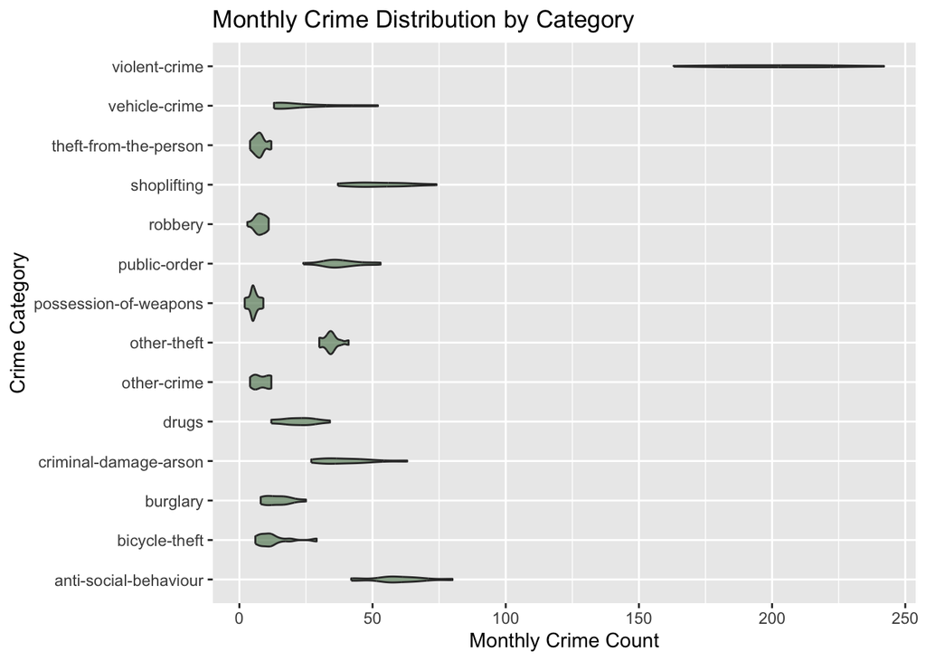

```r
# Preparing monthly crime count by category
crime_monthly_cat <- crime %>%
  mutate(month = floor_date(as.Date(date), unit = "month")) %>%
  group_by(month, category) %>%
  summarise(monthly_count = n(), .groups = "drop")

# Plotting monthly counts by category
ggplot(crime_monthly_cat, aes(x = category, y = monthly_count)) +
  geom_violin(fill = "darkseagreen4", alpha = 0.7) +
  coord_flip() +
  labs(
    title = "Monthly Crime Distribution by Category",
    x = "Crime Category",
    y = "Monthly Crime Count"
  )
```

*Figure 3: Violin plot showing the distribution of monthly crime counts for each category, highlighting variability and frequency across the year.*

**Violent crime** shows the highest monthly totals, with a broad distribution and occasional extreme values. **Anti-social behaviour** and **shoplifting** also exhibit relatively consistent and frequent occurrence across the year. In contrast, categories such as **bicycle theft**, **robbery**, and **possession of weapons** show low and narrowly distributed counts, suggesting these are less prevalent and more sporadic in nature.

### 3.5 Summary of Univariate Analysis

The univariate analysis reveals that crime in Colchester is concentrated in a few dominant categories, with violent crime and anti-social behaviour accounting for the majority of incidents. Monthly crime trends show a clear seasonal pattern, peaking during the summer months. Variation across categories is also notable, as some crimes display wide fluctuations month to month, while others remain relatively stable. These findings provide important context for the next stage, where we examine how weather factors may help explain these initial patterns.

## 4. Bivariate Analysis: Weather and Crime

This section explores the relationships between pairs of variables, with a particular focus on how weather conditions correlate with patterns in crime. By comparing crime counts with **temperature**, **rainfall**, and **humidity**, the analysis aims to assess whether these environmental factors are associated with measurable changes in criminal activity. Overall trends and crime-specific patterns are examined, using scatter plots, correlation coefficients, and linear smoothing techniques to quantify and visualise the strength and direction of these associations.

### 4.1 Correlation Overview

To begin the analysis, we examine the overall relationships between monthly crime counts and key weather variables using a correlation matrix. This provides a high-level view of how strongly each weather feature is associated with changes in crime. By visualising correlations between variables, we can identify which variables may warrant further investigation.

Strong correlations are indicated by larger circles and more saturated colors: red for positive associations and green for negative ones. Values near zero are highlighted in yellow and suggest little to no linear relationship.

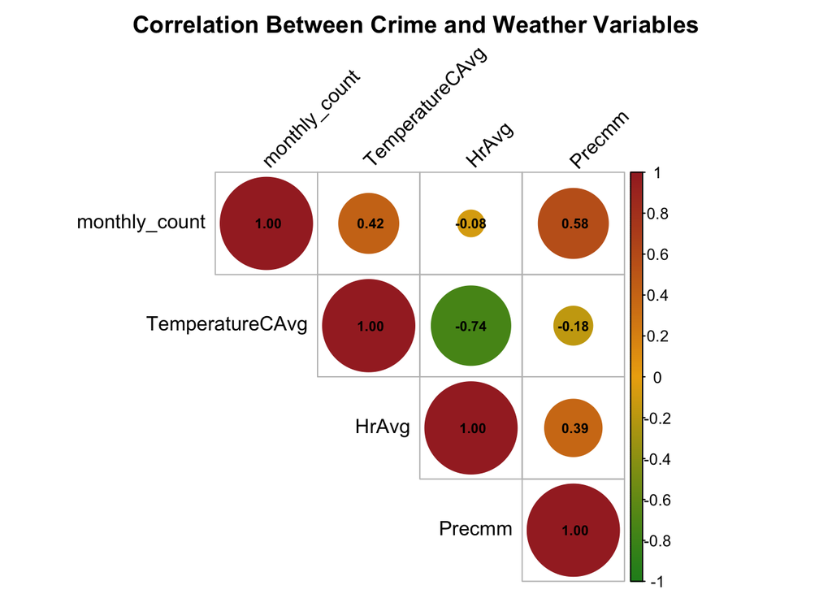

```r
# Selecting relevant variables and filtering out incomplete rows
cor_vars <- crime_weather_monthly %>%
  select(monthly_count, TemperatureCAvg, HrAvg, Precmm) %>%
  filter(complete.cases(.))

# Computing correlation matrix
cor_matrix <- cor(cor_vars)

# Plotting correlation matrix
corrplot(cor_matrix,
         method = "circle",
         type = "upper",
         addCoef.col = "black",
         number.cex = 0.7,
         tl.col = "black",
         tl.srt = 45,
         col = colorRampPalette(c("forestgreen", "darkgoldenrod2", "brown"))(200),
         title = "Correlation Between Crime and Weather Variables",
         mar = c(0, 0, 2, 0))
```

*Figure 4: Correlation matrix showing relationships between crime and weather variables. Stronger associations are shown by darker colors and larger labels.*

The results indicate a moderate positive correlation between crime and average temperature (r = 0.42), suggesting that higher temperatures may be associated with greater criminal activity. This aligns with the link between warmer weather and increased outdoor interaction, which can increase both opportunity and conflict-driven offenses. Interestingly, total monthly rainfall also shows a notable positive correlation with crime (r = 0.58), contradicting the common assumption that adverse weather suppresses crime. This may reflect the prevalence of indoor or opportunistic crimes during wet months.

Humidity, conversely, shows no meaningful relationship with crime (r = -0.08), implying limited relevance in this context. The matrix also highlights internal weather dynamics, with a strong negative correlation between temperature and humidity (r = -0.74) and a moderate positive correlation between humidity and rainfall (r = 0.39).

These findings provide a basis for selecting predictors in subsequent modeling. The next section builds on this by fitting a multiple linear regression model to evaluate the joint influence of temperature, precipitation, and humidity on monthly crime levels.

### 4.2 Temperature vs Monthly Crime

To explore if warmer weather is indeed associated with higher rates of crime, the monthly average temperature is compared with total crime counts per month. A linear regression line is included, along with Pearson’s correlation coefficient.

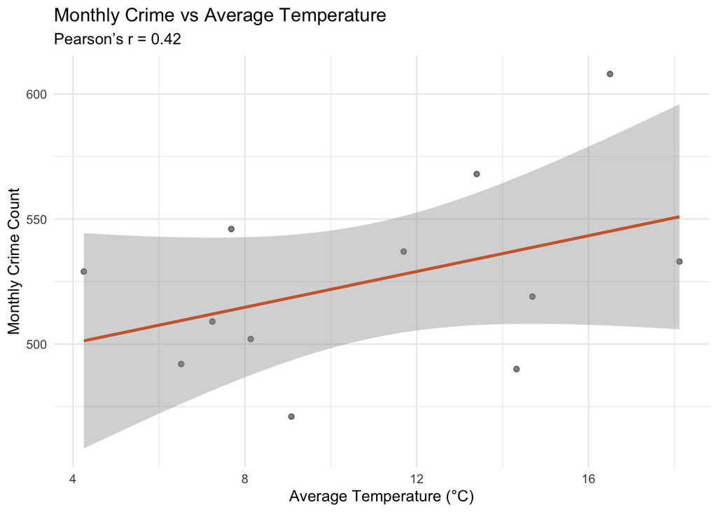

```r
# Working out correlation
cor_temp <- cor(crime_weather_monthly$TemperatureCAvg, crime_weather_monthly$monthly_count, use = "complete.obs")

# Plotting crime against temperature
ggplot(crime_weather_monthly, aes(x = TemperatureCAvg, y = monthly_count)) +
  geom_point(alpha = 0.5) +
  geom_smooth(method = "lm", se = TRUE, color = "sienna3") +
  labs(
    title = "Monthly Crime vs Average Temperature",
    subtitle = paste("Pearson’s r =", round(cor_temp, 2)),
    x = "Average Temperature (°C)",
    y = "Monthly Crime Count"
  ) +
  theme_minimal()
```

*Figure 5: Scatterplot of average monthly temperature vs total crime counts, with linear trend and correlation coefficient.*

This scatter plot presents the relationship between average monthly temperature and total **monthly crime counts**. The linear regression line (with a 95% confidence interval shaded in grey) shows a moderate positive association.

This indicates that, over the course of 2024, **crime levels tended to increase in warmer months**. While the relationship isn’t extremely strong, the upward trend suggests a potential seasonal pattern where elevated temperatures may be linked to more social activity or outdoor exposure, which could contribute to a rise in incidents. The confidence interval also widens at higher temperatures, suggesting greater variability in crime counts during summer months.

### 4.3 Rainfall vs Monthly Crime

Next, we examine how precipitation may relate to overall crime frequency. The plot below compares monthly rainfall totals (in mm) with corresponding crime counts. A linear fit and correlation value provide insight into the strength of the relationship.

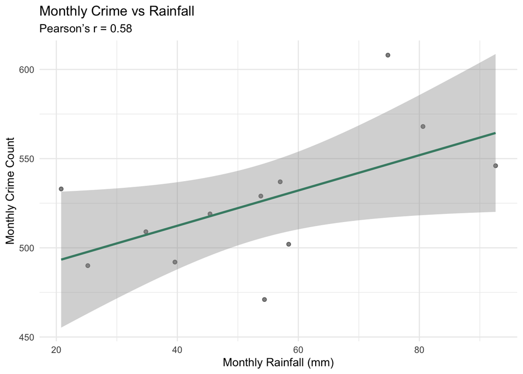

```r
# Working out orrelation
cor_rain <- cor(crime_weather_monthly$Precmm, crime_weather_monthly$monthly_count, use = "complete.obs")

# Plotting crime against rainfall
ggplot(crime_weather_monthly, aes(x = Precmm, y = monthly_count)) +
  geom_point(alpha = 0.5) +
  geom_smooth(method = "lm", se = TRUE, color = "aquamarine4") +
  labs(
    title = "Monthly Crime vs Rainfall",
    subtitle = paste("Pearson’s r =", round(cor_rain, 2)),
    x = "Monthly Rainfall (mm)",
    y = "Monthly Crime Count"
  ) +
  theme_minimal()
```

*Figure 6: Scatterplot of total monthly rainfall vs crime counts, with linear fit and Pearson’s r.*

As explained previously, we may expect **rainy conditions to deter outdoor crimes**. However, the observed correlation may be driven by confounding seasonal factors: for instance, summer months in Colchester may feature occasional storms yet still have higher activity levels, increasing the chance for crime.

### 4.4 Temperature vs Monthly Crime Count for Top Categories

To focus on broader seasonal trends and filter out noise, we aggregate crime data by month and examine how monthly average temperature relates to crime frequency across the five most common crime types in Colchester.

The plots below show one point per month (n = 12 per category), with a linear regression line and Pearson’s r and p-values included to assess the strength and significance of each relationship.

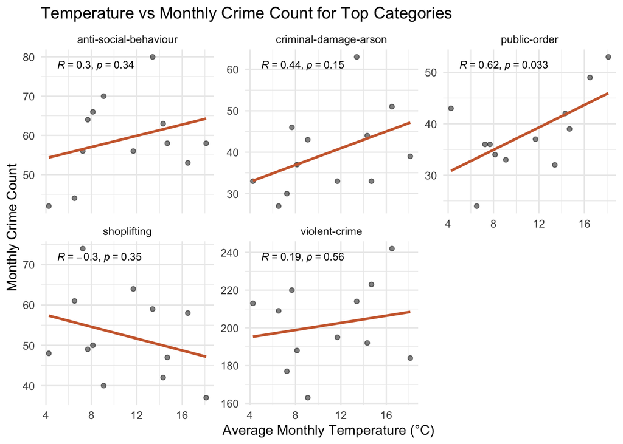

```r
# Top 5 categories by frequency
top_types <- crime %>%
  count(category, sort = TRUE) %>%
  slice_max(n, n = 5) %>%
  pull(category)

# Aggregate by month and category
crime_weather_by_cat <- crime %>%
  filter(category %in% top_types) %>%
  mutate(month = floor_date(date, "month")) %>%
  count(month, category, name = "monthly_count") %>%
  left_join(weather_monthly, by = "month")

# Plot temperature vs crime count for top 5
ggplot(crime_weather_by_cat, aes(x = TemperatureCAvg, y = monthly_count)) +
  geom_point(alpha = 0.5) +
  geom_smooth(method = "lm", se = FALSE, color = "sienna3") +
  stat_cor(method = "pearson", size = 3, label.x = 5) +
  facet_wrap(~ category, scales = "free_y") +
  labs(
    title = "Temperature vs Monthly Crime Count for Top Categories",
    x = "Average Monthly Temperature (°C)",
    y = "Monthly Crime Count"
  ) +
  theme_minimal()
```

*Figure 7: Faceted scatterplots showing the relationship between temperature and monthly crime counts for five key categories.*

Figure 7 shows how monthly crime counts for the five most frequent crime types vary with average monthly temperature. The only statistically significant positive relationship is observed for **public-order offences** (R = 0.62, p = 0.033), further suggesting that warmer months are associated with increased disorder-related incidents.

For **anti-social behaviour** and **criminal damage/arson**, positive correlations are also observed, although these are not statistically significant (R = 0.30 and R = 0.44, respectively). Conversely, **shoplifting** shows a weak negative correlation (R = -0.30), possibly indicating reduced indoor retail theft in warmer weather, though again this result is not significant. **Violent crime** shows very little association with temperature (R = 0.19, p = 0.56).

These findings suggest that weather–crime relationships are not uniform across crime types. Where associations do appear, they are likely influenced by crime context—e.g., crimes occurring in public or outdoor spaces may be more temperature-sensitive.

### 4.5 Rainfall vs Monthly Crime Count for Top Categories

Here, we examine how monthly average rainfall relates to crime frequency across the five most common crime types in Colchester. Similarly to Figure 7, plots below show one point per month, with a linear regression line and Pearson’s r and p-values.

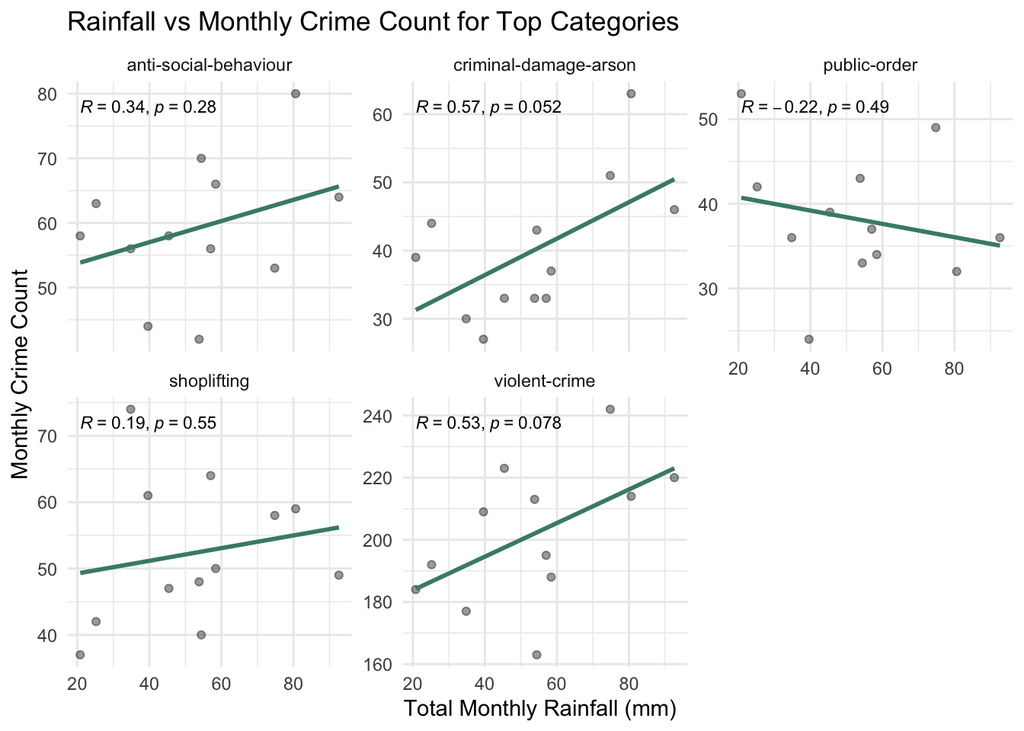

```r
# Plot rainfall vs crime count for top 5
ggplot(crime_weather_by_cat, aes(x = Precmm, y = monthly_count)) +
  geom_point(alpha = 0.4) +
  geom_smooth(method = "lm", se = FALSE, color = "aquamarine4") +
  stat_cor(method = "pearson", size = 3) +
  facet_wrap(~ category, scales = "free_y") +
  labs(
    title = "Rainfall vs Monthly Crime Count for Top Categories",
    x = "Total Monthly Rainfall (mm)",
    y = "Monthly Crime Count"
  ) +
  theme_minimal()
```

*Figure 8: Faceted scatterplots showing the relationship between rainfall and monthly crime counts for five key categories.*

The faceted scatterplot shows the relationship between **total monthly rainfall** and **monthly crime counts** across the five most common crime categories.

A **moderate positive relationship** is observed for **criminal damage and arson** (R = 0.57, p = 0.052) and **violent crime** (R = 0.53, p = 0.078), suggesting that these categories tend to see slightly elevated incident counts during wetter months, although statistical significance remains marginal.

For **anti-social behaviour**, the association is weaker (R = 0.34, p = 0.28), while **shoplifting** shows a weaker and statistically insignificant correlation (R = 0.19, p = 0.55). Interestingly, **public order offences** are the only category with a negative correlation (R = -0.22, p = 0.49), hinting that rain may slightly suppress public gatherings or demonstrations where such offences typically occur.

Taken together, these plots reveal that **rainfall effects on crime are not uniform**: while some categories show mild positive associations, others appear unaffected or inversely related.

### 4.6. Summary of Bivariate Insights

**Criminal damage and arson** and **violent crime** show moderate positive associations with total monthly rainfall, hinting that wetter conditions may indirectly influence stress, indoor conflict, or opportunistic crimes. However, **public order offences** display a mild negative relationship, suggesting a possible dampening effect of rain on public events.

Overall, these results indicate that **environmental effects on crime vary across offence types**, with temperature and precipitation influencing certain behaviours more than others. This reinforces the need for disaggregated models when exploring weather–crime dynamics.

## 5. Spatial Crime Analysis

This section maps the geographic distribution of major crime categories across Colchester using street-level incident data. By visualising hotspots for offences like **violent crime** and **anti-social behaviour**, we aim to identify spatial patterns and areas of persistent criminal activity.

### 5.1 Crime Density Mapping

To explore spatial crime concentration, we plot a kernel density heatmap using all recorded crime locations in Colchester. This highlights general hotspots without distinguishing by crime type.

```r
# Creating a density heatmap
leaflet(crime) %>%
  addTiles() %>%
  addHeatmap(lng = ~long, lat = ~lat, blur = 20, max = 0.05, radius = 15)
```

[interactive chart not shown]

*Figure 9: Leaflet heatmap showing overall spatial crime intensity across Colchester in 2024.*

The density map reveals that crime is heavily concentrated around the **town centre** and **transport corridors**. These locations likely experience more foot traffic and opportunity-driven incidents. The residential zones show less activity overall.

### 5.2 Interactive Crime Map by Category

To better understand spatial variation by crime type, we create an interactive leaflet map with a toggle allowing users to filter by category. Each dot represents a crime location, color-coded by type, and can be filtered dynamically.

```r
# Working out top crime types by category for the leaflet layers
crime_layers <- top_types %>%
  map(function(cat) crime %>% filter(category == cat))

# Creating the colour palate and assigning them to categories
layer_colors <- c("brown", "orange", "yellow", "darkolivegreen", "cadetblue")
names(layer_colors) <- top_types

# Creating the leaflet map
map <- leaflet() %>% addProviderTiles("CartoDB.Positron")
for (i in seq_along(top_types)) {
  map <- map %>%
    addCircleMarkers(
      data = crime_layers[[i]],
      lng = ~long, lat = ~lat,
      popup = ~paste("Crime:", category, "<br>Street:", street_name),
      color = layer_colors[[i]],
      radius = 4, fillOpacity = 0.6, stroke = FALSE,
      group = top_types[[i]]
    )
}
map <- map %>%
  addLayersControl(
    overlayGroups = top_types,
    options = layersControlOptions(collapsed = FALSE)
  ) %>%
  addLegend("bottomright", colors = layer_colors, labels = top_types, title = "Crime Types")
map
```

[interactive chart not shown]

*Figure 10: Interactive Leaflet map showing spatial distribution of crimes, filterable by category.*

## 6. Temporal and Spatial Interaction of Crime and Weather

While the prior bivariate analysis examined pairwise relationships between individual weather variables and crime, this section explores how these interactions unfold over time and across space. By examining temporal trends and spatial concentrations in tandem with environmental conditions, we aim to identify more nuanced patterns — for example, whether warmer months see different crime compositions in certain neighbourhoods.

### 6.1 Monthly Trends: Crime and Weather Side-by-Side

To explore seasonal patterns in crime alongside weather conditions, we plot average monthly temperature and rainfall against total monthly crime counts. This allows for a visual comparison of their temporal alignment and potential lag effects. The solid line tracks the monthly crime totals, while the dashed line represents the average temperature for each month (rescaled for visual comparability).

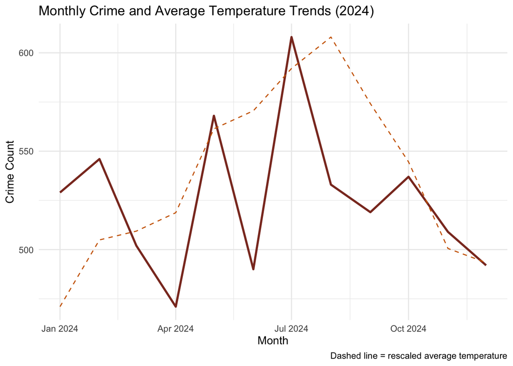

```r
library(scales)

# Plotting monthly crime against temperature
ggplot(crime_weather_monthly, aes(x = month)) +
  geom_line(aes(y = monthly_count), color = "tomato4", size = 1) +
  geom_line(aes(y = scales::rescale(TemperatureCAvg, to = range(monthly_count))),
            color = "darkorange3", linetype = "dashed") +
  labs(
    title = "Monthly Crime and Average Temperature Trends (2024)",
    x = "Month",
    y = "Crime Count",
    caption = "Dashed line = rescaled average temperature"
  ) +
  theme_minimal()
```

Overall, the general alignment between the two trends, especially their shared rise from winter to summer and decline into autumn, **hints at a loose positive association between temperature and total crime**. Still, deviations in specific months (e.g., April and August) indicate that other factors beyond temperature are likely shaping monthly variation. This figure offers a useful temporal snapshot and sets the stage for more targeted statistical analyses in the sections to follow.

### 6.2 Weather-Based Spatial Mapping

To fully explore the interaction between weather and crime, we examine not only when these variables shift over time, but also where their effects are most pronounced across Colchester. By comparing spatial crime distributions for the top 5 crime types across different weather conditions, we assess whether certain areas are more sensitive to environmental changes.

```r
# Assigning months to seasons
crime_season <- crime %>%
  mutate(
    month = month(date),
    season = case_when(
      month %in% c(12, 1, 2)  ~ "Winter",
      month %in% c(3, 4, 5)   ~ "Spring",
      month %in% c(6, 7, 8)   ~ "Summer",
      month %in% c(9, 10, 11) ~ "Autumn"
    )
  )

# Filtering for top crime types
crime_season_filtered <- crime_season %>%
  filter(category %in% top_types)

# Creating the visualisation
leaflet() %>%
  addTiles() %>%

  addCircleMarkers(
    data = filter(crime_season_filtered, season == "Winter"),
    ~long, ~lat,
    color = "cadetblue", radius = 3, fillOpacity = 0.6,
    group = "Winter",
    popup = ~category
  ) %>%

  addCircleMarkers(
    data = filter(crime_season_filtered, season == "Spring"),
    ~long, ~lat,
    color = "olivedrab", radius = 3, fillOpacity = 0.6,
    group = "Spring",
    popup = ~category
  ) %>%

  addCircleMarkers(
    data = filter(crime_season_filtered, season == "Summer"),
    ~long, ~lat,
    color = "brown", radius = 3, fillOpacity = 0.6,
    group = "Summer",
    popup = ~category
  ) %>%

  addCircleMarkers(
    data = filter(crime_season_filtered, season == "Autumn"),
    ~long, ~lat,
    color = "orange", radius = 3, fillOpacity = 0.6,
    group = "Autumn",
    popup = ~category
  ) %>%

  addLayersControl(
    overlayGroups = c("Winter", "Spring", "Summer", "Autumn"),
    options = layersControlOptions(collapsed = FALSE)
  )
```

[interactive chart not shown]

*Figure 12: Interactive leaflet map displaying seasonal crime patterns for the top 5 crime categories in Colchester. Use the layer control to switch between seasons.*

This interactive leaflet map displays the spatial distribution of the top five crime types across Colchester, segmented by season. A key spatial pattern emerges: **Colchester town centre consistently appears as a high-density hotspot**, regardless of season. This concentration suggests a strong association between crime activity and areas of high foot traffic, commerce, and nightlife.

Whilst the spatial elements remain similar, **seasonal differences in spread and intensity** are evident. **Summer** and **autumn** exhibit slightly broader dispersion, with more incidents radiating out from the centre. **Winter** crimes are more tightly clustered around the centre, potentially due to reduced mobility and colder weather discouraging further travel.

By layering both temporal and spatial dimensions, this map effectively highlights the **persistent urban hotspots** and the **seasonal nuances** in crime distribution.

### 6.3 Linear Model: Does Weather Predict Crime?

To quantify the combined effect of temperature and rainfall, we fit a linear regression model using monthly crime count for the 5 most frequent crimes as the dependent variable.

```r
top5_crime_monthly <- crime %>%
  filter(category %in% top_types) %>%
  mutate(month = floor_date(as.Date(date), unit = "month")) %>%
  group_by(month) %>%
  summarise(monthly_count = n(), .groups = "drop")

# Merge with weather data
top5_crime_weather_monthly <- left_join(top5_crime_monthly, weather_monthly, by = "month")

# Fit linear model with weather variables
model_top5 <- lm(monthly_count ~ TemperatureCAvg + Precmm + HrAvg, data = top5_crime_weather_monthly)

# Tidy model summary
tidy(model_top5) %>%
  kable(caption = "Table 2: Linear Regression Results for Top 5 Crime Types and Weather Variables")
```

Table 2: Linear Regression Results for Top 5 Crime Types and Weather Variables

| term | estimate | std.error | statistic | p.value |
| --- | --- | --- | --- | --- |
| (Intercept) | 201.5830450 | 142.4368639 | 1.4152449 | 0.1947235 |
| TemperatureCAvg | 4.8892770 | 1.9357430 | 2.5257883 | 0.0354874 |
| Precmm | 1.0652153 | 0.2856976 | 3.7284711 | 0.0058005 |
| HrAvg | 0.9729094 | 1.6000427 | 0.6080522 | 0.5600149 |

This model reveals that **average temperature and total monthly rainfall are both significant predictors** of monthly crime counts within the most common categories. The temperature coefficient (4.89) suggests that for each 1°C increase in monthly average temperature, there are approximately **5 more crime incidents** among the top 5 types — a finding aligned with earlier scatterplot trends.

Rainfall has an even stronger effect: for every 1 mm increase in precipitation, there is approximately **1 additional incident**, which may seem counterintuitive but mirrors patterns seen in earlier rainfall-crime correlation and regression visuals. This could reflect behavioural changes (e.g., people staying in crowded indoor spaces).

Humidity again remains non-significant (p = 0.56), indicating it doesn’t strongly influence variation in crime for these types.

## 7. Conclusion

This report set out to examine how weather conditions relate to patterns of street-level crime in Colchester during 2024, with particular attention to temperature, rainfall, and humidity. Using a combination of descriptive statistics, correlation analysis, spatial mapping, and linear modelling, the analysis explored how these environmental factors interact with crime across both time and space.

Overall, the evidence suggests that while weather alone does not drive crime in a uniform way, it may influence certain types of crime under specific conditions. The findings advocate for a more segmented approach to crime-environment analysis, one that accounts for temporal cycles, geographic concentration, and behavioural context. Future work could build on this by incorporating multi-year data, socio-economic indicators, and more advanced spatio-temporal modelling frameworks to better capture the complexity of urban crime dynamics.

In conclusion, this analysis shows that the impact of weather on crime in Colchester during 2024 is nuanced and conditional, rather than uniform or dominant. Temperature and rainfall can influence specific crime types, particularly those tied to mobility and public space, but broader trends appear to be more strongly shaped by spatial location and seasonal rhythms than by environmental variables alone.